# RNA-Seq Analysis

Vittorio Calcagno

15 July, 2022

# Abstract

A differential expression (DE) analysis is presented on a dataset obtained from a paper published by Lund K, Cole JJ. et al. with name “DNMT inhibitors reverse a specific signature of aberrant promoter DNA methylation and associated gene silencing in AML” (https://pubmed.ncbi.nlm.nih.gov/25315154/).

The dataset contains RNA-Seq counts for OCI-AML3 cells treated with azacytidine and untreated cells as control.

OCI-AML3 cells carry an NPM1 gene mutation (type A) and the DNMT3A R882C mutation (http://www.ebi.ac.uk/efo/EFO_0006289).

Azacytidine, a cytidine analogue, inhibits DNA methyltransferase, resulting in hypomethylation of promoter regions. It is an approved treatment used in myelodysplastic syndrome (MDS) and myeloid leukemia (ML).

Analysis shows several differentially expressed genes, more in the over expressed side than in the under expressed side, with a similar pattern observed in differentially expressed pathways, obtained by gene set enrichment analysis (GSEA). It is hypothesized that this could be related to the fact that treatment with hypomethylating agents results in increased gene expression.

Treatment with azacytidine results in suppression of pathways related to cell proliferation and activation of pathways signature of leukocytes differentiation and immune response. It is hypothesized that this effect could explain the effectiveness of the treatment in the disease in question, that is characterized by uncontrolled proliferation of hematopoetic (hence undifferentiated) cells.

# Setup

## Bioconductor packages installation

The following code chunk is not run automatically, however the Bioconductor packages are required for running this Rmd. Please manually run this code chunk if any of the packages are missing, or just run it to check.

```r
if (!require("BiocManager", quietly = TRUE)) {
  install.packages("BiocManager")
}

BiocManager::install("recount")
BiocManager::install("DESeq2")
BiocManager::install("apeglm")
BiocManager::install("EnhancedVolcano")
BiocManager::install("EnsDb.Hsapiens.v86")
BiocManager::install("clusterProfiler")
```

## Download recount project data

```r
project <- "SRP038101"

recount_filepath <- file.path(project, "rse_gene.Rdata")

if (!file.exists(recount_filepath)) {
  download_study(project)
}

load(recount_filepath)
```

The recount data for project *SRP038101* is provided with this Rmd, however it would be automatically downloaded if missing.

## Download SRA metadata

The metadata (biological condition of samples) is obtained from NCBI’s SRA.

**Python virtual environment requirement: Please note the csv file with SRA metadata is already included with this Rmd, the following is only required if its desired to download the csv file from its original source**

A Python packages named SRAweb is required to download SRA data, this package is installed in a virtual environment in ./env sub-directory of the Rmd working directory.

Please follow instructions in readme.MD to create the Python virtual environment and install SRAweb package.

```r
get_sra_metadata <- function(project) {
  file_name <- file.path(project, glue("{project}_metadata.csv"))

  if (!file.exists(file_name)) {
    # Activate Python virtual environment
    if (.Platform$OS.type == "windows") {
      use_python("env/Scripts")
    } else {
      use_python("env/bin")
    }

    py_run_string(glue(
      "
    from pysradb import SRAweb
    db = SRAweb()
    df = db.sra_metadata('{project}', detailed=True)
    file_name = '{file_name}'
    df.to_csv(file_name, index = False)
    print('Project {project} metadata was saved to ' + file_name)
    "
    ))
  }

  read.csv(file_name, row.names = NULL)
}


data_meta <- get_sra_metadata(project)

datatable(data_meta, caption = "SRA Metadata", options = list(
  pageLength = 10, scrollX = "400px"
))
```

|  | run_accession | study_accession | study_title | experiment_accession | experiment_title | experiment_desc | organism_taxid | organism_name | library_name | library_strategy | library_source | library_selection | library_layout | sample_accession | sample_title | instrument | instrument_model | instrument_model_desc | total_spots | total_size | run_total_spots | run_total_bases | run_alias | sra_url_alt1 | sra_url_alt2 | sra_url | GCP_url | GCP_free_egress | GCP_access_type | … |
| --- | --- | --- | --- | --- | --- | --- | --- | --- | --- | --- | --- | --- | --- | --- | --- | --- | --- | --- | --- | --- | --- | --- | --- | --- | --- | --- | --- | --- | --- | --- |
| 1 | SRR1171528 | SRP038101 | Expression data from untreated and Aza treated AML3 cells | SRX472612 | GSM1329864: Treated.3; Homo sapiens; RNA-Seq | GSM1329864: Treated.3; Homo sapiens; RNA-Seq | 9606 | Homo sapiens |  | RNA-Seq | TRANSCRIPTOMIC | cDNA | PAIRED | SRS559069 |  | Illumina Genome Analyzer IIx | Illumina Genome Analyzer IIx | ILLUMINA | 22201148 | 890427999 | 22201148 | 1598482656 | GSM1329864_r1 | gs://sra-pub-src-11/SRR1171528/KL6_R2.fastq.gz | s3://sra-pub-src-11/SRR1171528/KL6_R2.fastq.gz | https://sra-pub-run-odp.s3.amazonaws.com/sra/SRR1171528/SRR1171528 | gs://sra-pub-crun-1/SRR1171528/SRR1171528.1 | - | Use Cloud Data Delivery | … |
| 2 | SRR1171527 | SRP038101 | Expression data from untreated and Aza treated AML3 cells | SRX472611 | GSM1329863: Treated.2; Homo sapiens; RNA-Seq | GSM1329863: Treated.2; Homo sapiens; RNA-Seq | 9606 | Homo sapiens |  | RNA-Seq | TRANSCRIPTOMIC | cDNA | PAIRED | SRS559067 |  | Illumina Genome Analyzer IIx | Illumina Genome Analyzer IIx | ILLUMINA | 23603785 | 949179095 | 23603785 | 1699472520 | GSM1329863_r1 | gs://sra-pub-src-4/SRR1171527/KL5_R2.fastq.gz | s3://sra-pub-src-4/SRR1171527/KL5_R2.fastq.gz | https://sra-pub-run-odp.s3.amazonaws.com/sra/SRR1171527/SRR1171527 | gs://sra-pub-crun-1/SRR1171527/SRR1171527.1 | - | Use Cloud Data Delivery | … |
| 3 | SRR1171526 | SRP038101 | Expression data from untreated and Aza treated AML3 cells | SRX472610 | GSM1329862: Treated.1; Homo sapiens; RNA-Seq | GSM1329862: Treated.1; Homo sapiens; RNA-Seq | 9606 | Homo sapiens |  | RNA-Seq | TRANSCRIPTOMIC | cDNA | PAIRED | SRS559068 |  | Illumina Genome Analyzer IIx | Illumina Genome Analyzer IIx | ILLUMINA | 22761023 | 920225362 | 22761023 | 1638793656 | GSM1329862_r1 | gs://sra-pub-src-12/SRR1171526/KL4_R2.fastq.gz | s3://sra-pub-src-12/SRR1171526/KL4_R2.fastq.gz | https://sra-pub-run-odp.s3.amazonaws.com/sra/SRR1171526/SRR1171526 | gs://sra-pub-crun-1/SRR1171526/SRR1171526.1 | - | Use Cloud Data Delivery | … |
| 4 | SRR1171525 | SRP038101 | Expression data from untreated and Aza treated AML3 cells | SRX472609 | GSM1329861: Untreated.3; Homo sapiens; RNA-Seq | GSM1329861: Untreated.3; Homo sapiens; RNA-Seq | 9606 | Homo sapiens |  | RNA-Seq | TRANSCRIPTOMIC | cDNA | PAIRED | SRS559065 |  | Illumina Genome Analyzer IIx | Illumina Genome Analyzer IIx | ILLUMINA | 22733713 | 915380991 | 22733713 | 1636827336 | GSM1329861_r1 | gs://sra-pub-src-14/SRR1171525/KL3_R2.fastq.gz | s3://sra-pub-src-14/SRR1171525/KL3_R2.fastq.gz | https://sra-pub-run-odp.s3.amazonaws.com/sra/SRR1171525/SRR1171525 | gs://sra-pub-crun-1/SRR1171525/SRR1171525.1 | - | Use Cloud Data Delivery | … |
| 5 | SRR1171524 | SRP038101 | Expression data from untreated and Aza treated AML3 cells | SRX472608 | GSM1329860: Untreated.2; Homo sapiens; RNA-Seq | GSM1329860: Untreated.2; Homo sapiens; RNA-Seq | 9606 | Homo sapiens |  | RNA-Seq | TRANSCRIPTOMIC | cDNA | PAIRED | SRS559066 |  | Illumina Genome Analyzer IIx | Illumina Genome Analyzer IIx | ILLUMINA | 22249300 | 899714745 | 22249300 | 1601949600 | GSM1329860_r1 | gs://sra-pub-src-13/SRR1171524/KL2_R2.fastq.gz | s3://sra-pub-src-13/SRR1171524/KL2_R2.fastq.gz | https://sra-pub-run-odp.s3.amazonaws.com/sra/SRR1171524/SRR1171524 | gs://sra-pub-crun-1/SRR1171524/SRR1171524.1 | - | Use Cloud Data Delivery | … |
| 6 | SRR1171523 | SRP038101 | Expression data from untreated and Aza treated AML3 cells | SRX472607 | GSM1329859: Untreated.1; Homo sapiens; RNA-Seq | GSM1329859: Untreated.1; Homo sapiens; RNA-Seq | 9606 | Homo sapiens |  | RNA-Seq | TRANSCRIPTOMIC | cDNA | PAIRED | SRS559064 |  | Illumina Genome Analyzer IIx | Illumina Genome Analyzer IIx | ILLUMINA | 25764793 | 1040217731 | 25764793 | 1855065096 | GSM1329859_r1 | gs://sra-pub-src-14/SRR1171523/KL1_R2.fastq.gz | s3://sra-pub-src-14/SRR1171523/KL1_R2.fastq.gz | https://sra-pub-run-odp.s3.amazonaws.com/sra/SRR1171523/SRR1171523 | gs://sra-pub-crun-1/SRR1171523/SRR1171523.1 | - | Use Cloud Data Delivery | … |

## Data wrangling and loading into DESeq

```r
condition_column <- "treatment"
```

The biological condition of interest to investigate would be *treatment*, given by the column of the same name.

```r
df_count <- assays(rse_gene) %>%
  as.data.frame() %>%
  select(-c(1:2)) %>%
  filter_all(any_vars(. != 0)) %>%
  rownames_to_column() %>%
  mutate(rowname = gsub(rowname, pattern = "\\..+", replacement = "")) %>%
  column_to_rownames()

df_meta <- data_meta %>%
  as_tibble() %>%
  # subset(!is.na(hba1c)) %>%
  rename(condition = as.symbol(condition_column)) %>% # treatment
  # separate(phenotype, c("condition"), sep = "_") %>%
  select(run_accession, condition) %>%
  arrange(run_accession) %>%
  subset(run_accession %in% colnames(df_count)) %>%
  column_to_rownames(var = "run_accession") %>%
  mutate(condition = str_replace_all(tolower(condition), " ", "_"))

kable(df_meta, caption = "Samples by biological condition")
```

Samples by biological condition

|  | condition |
| --- | --- |
| SRR1171523 | aza_treated |
| SRR1171524 | aza_treated |
| SRR1171525 | aza_treated |
| SRR1171526 | untreated |
| SRR1171527 | untreated |
| SRR1171528 | untreated |

```r
# Using relevel to set the correct resultNames coefficients for lfcShrink

condition_base <- "untreated"
condition_contrast <- "aza_treated"

df_meta$condition <- relevel(as.factor(df_meta$condition), condition_base)

idx <- match(rownames(df_meta), colnames(df_count))
df_count <- df_count[, idx]

assert(all(colnames(df_count) %in% rownames(df_meta)))
assert(all(colnames(df_count) == rownames(df_meta)))
```

```r
# Load data into dds object
dds <- DESeqDataSetFromMatrix(
  countData = df_count,
  colData = df_meta,
  design = ~condition
)

dds <- estimateSizeFactors(dds)
```

# Quality assessment

Quality assessment is performed below in order to understand how the data will perform in a differential gene expression analysis.

## PCA Plot

```r
intgroup <- c("condition")

# Normalize and transform counts
vsd_all <- vst(dds, blind = TRUE)
```

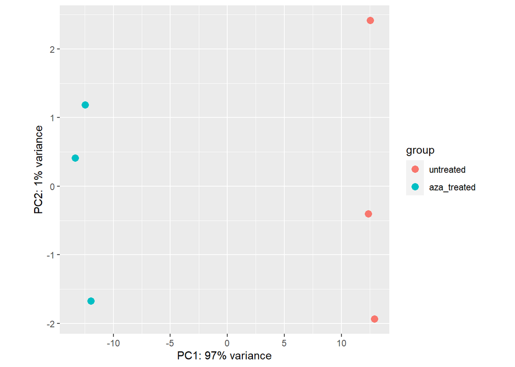

```r
plotPCA(vsd_all, intgroup = intgroup) + theme(aspect.ratio = 1)
```

The PCA plot, colored by condition of interest, looks promising, accounting for 97% among the first principal component dimension, and showing tight clusters with clear separation across groups.

## Dispersion

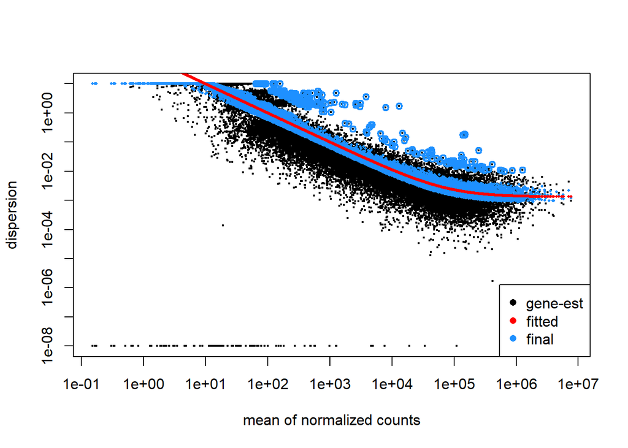

```r
dds <- DESeq(dds)

plotDispEsts(dds)
```

`Dispersion` vs `Mean of normalized counts` is plotted in order to see that the general assumption of the DESeq model holds, i.e. the dispersion decreases as the mean of (normalized) counts increases. In this case it can be observed that the general assumption of the model holds very well.

# DESeq results and shrinkage

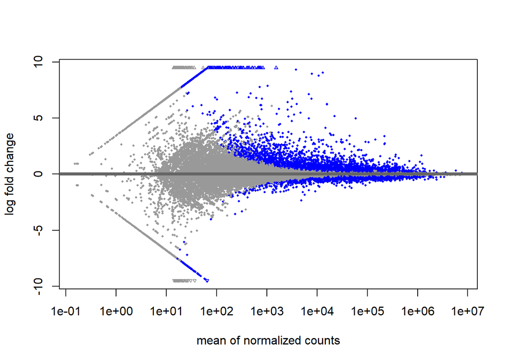

```r
alpha <- 0.05
dds_res <- results(dds,
  contrast = c("condition", condition_contrast, condition_base),
  alpha = alpha
)

plotMA(dds_res)
```

DESeq results are obtained, and a plot of `Log fold change` vs `Mean of normalized counts` is presented, showing significant results in blue (with a threshold of 0.05 for significance level). It can be observed that the points follow a somewhat normal distribution, with a long tail at the significant (blue) side.

```r
dds_res_shrink <- lfcShrink(dds, coef = 2, res = dds_res, type = "apeglm")
```

```
## using 'apeglm' for LFC shrinkage. If used in published research, please cite:
##     Zhu, A., Ibrahim, J.G., Love, M.I. (2018) Heavy-tailed prior distributions for
##     sequence count data: removing the noise and preserving large differences.
##     Bioinformatics. https://doi.org/10.1093/bioinformatics/bty895
```

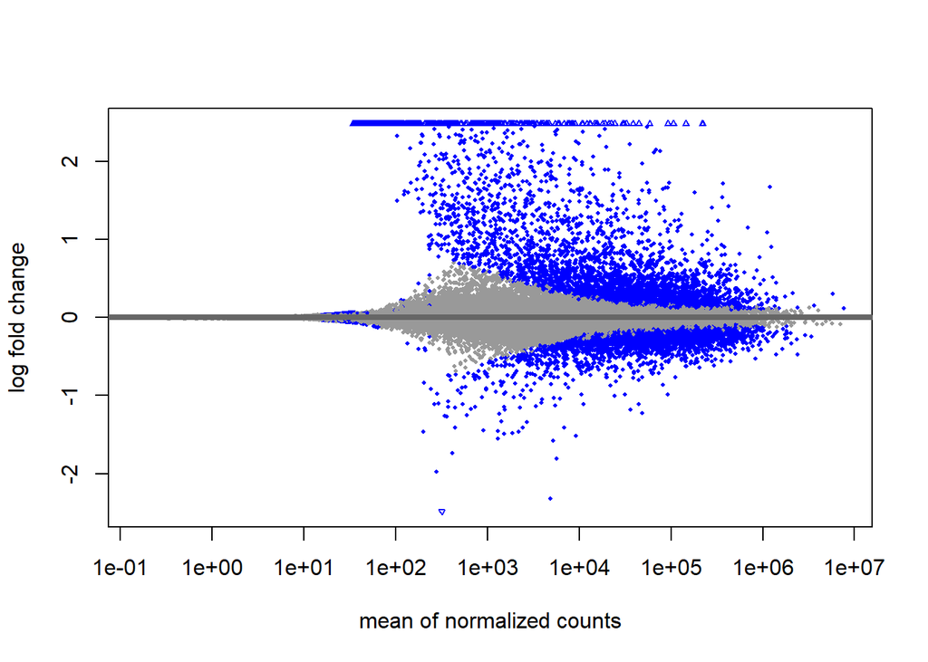

```r
plotMA(dds_res_shrink)
```

Coefficient shrinkage is performed, showing favorable effects in the distribution of `Log fold change` vs `Mean of normalized counts`, which now shows a more normal distribution.

```r
ens2sym <- AnnotationDbi::select(EnsDb.Hsapiens.v86,
  keys = keys(EnsDb.Hsapiens.v86),
  columns = c("SYMBOL")
)

# Data is subsetted to contain only non NA padj
# Reason for this is explained in the documentation:
# https://bioconductor.org/packages/release/bioc/vignettes/DESeq2/inst/doc/DESeq2.html#pvaluesNA
# TLDR: NA padj are either 0 count or outliers

resdf <- dds_res %>%
  data.frame() %>%
  subset(!is.na(padj)) %>%
  subset(!is.na(stat)) %>%
  rownames_to_column() %>%
  mutate(GENEID = gsub(rowname, pattern = "\\..+", replacement = "")) %>%
  dplyr::select(-rowname) %>%
  inner_join(y = ens2sym, by = "GENEID") %>%
  mutate(padj = case_when(padj == 0 ~ .Machine$double.xmin, TRUE ~ padj)) %>%
  arrange(desc(stat))

resdf_shrink <- dds_res_shrink %>%
  data.frame() %>%
  mutate(stat = log2FoldChange / lfcSE) %>%
  subset(!is.na(padj)) %>%
  subset(!is.na(stat)) %>%
  rownames_to_column() %>%
  mutate(GENEID = gsub(rowname, pattern = "\\..+", replacement = "")) %>%
  dplyr::select(-rowname) %>%
  inner_join(y = ens2sym, by = "GENEID") %>%
  mutate(padj = case_when(padj == 0 ~ .Machine$double.xmin, TRUE ~ padj)) %>%
  arrange(desc(stat))
```

# Differentially expressed genes table

```r
resdf_shrink_sig <- resdf_shrink %>%
  subset(log2FoldChange > 2 & padj < 0.05) %>%
  select(GENEID, SYMBOL, log2FoldChange, padj, stat)


datatable(resdf_shrink_sig, options = list(
  pageLength = 10, scrollX = "400px"
))
```

|  | GENEID | SYMBOL | log2FoldChange | padj | stat |
| --- | --- | --- | --- | --- | --- |
| 1 | ENSG00000164692 | COL1A2 | 5.16890071357645 | 2.2250738585072e-308 | 63.8867138777597 |
| 2 | ENSG00000165949 | IFI27 | 3.38168719282477 | 2.2250738585072e-308 | 45.4659811629067 |
| 3 | ENSG00000070915 | SLC12A3 | 3.40013010188455 | 2.2250738585072e-308 | 44.232342696664 |
| 6 | ENSG00000189060 | H1F0 | 3.4861825083754 | 1.88221647098519e-270 | 35.3225851188289 |
| 8 | ENSG00000198865 | CCDC152 | 7.11174567589717 | 1.51918995312336e-250 | 33.9765969129228 |
| 9 | ENSG00000187608 | ISG15 | 2.86912427845779 | 3.69362639425241e-232 | 32.7377175671175 |
| 11 | ENSG00000114013 | CD86 | 2.82994621348659 | 5.84203153662021e-200 | 30.3713209218424 |
| 12 | ENSG00000108679 | LGALS3BP | 3.46306721993286 | 7.73011676921442e-200 | 30.3522737936812 |
| 13 | ENSG00000147804 | SLC39A4 | 5.46704442419399 | 3.95529035607362e-195 | 29.972521607571 |
| 14 | ENSG00000120708 | TGFBI | 3.05447277807637 | 5.83776734662684e-190 | 29.5661384769059 |

[output cut: 449 more lines]

# Volcano Plot

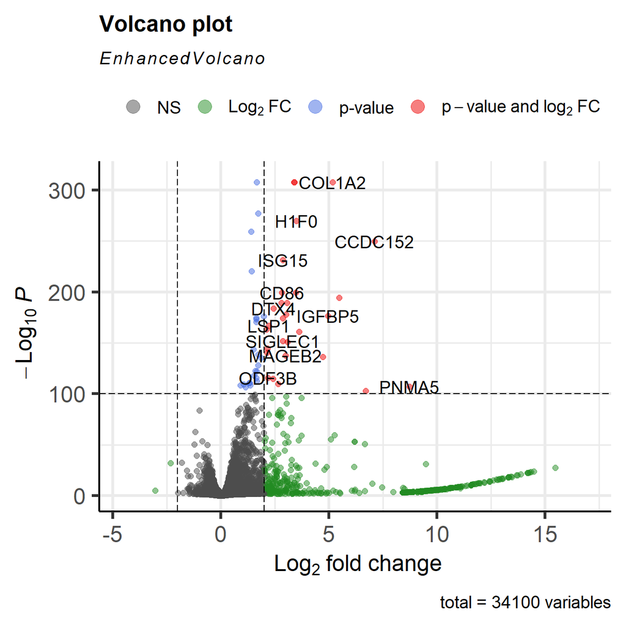

```r
p_cutoff <- 1e-100
fc_cutoff <- 2
ev <- EnhancedVolcano(resdf_shrink,
  lab = resdf_shrink$SYMBOL,
  pCutoff = p_cutoff,
  FCcutoff = fc_cutoff, x = "log2FoldChange", y = "padj"
)
ev
```

The Volcano Plot shows only a few (n = 29) genes above the FC and P value thresholds in the over-expression side, and 0 in the under-expression side, in other words, there are more genes significantly differentially over expressed than under expressed.

This could be related to the fact that azacytidine is an hypomethylating agent, that results in elevated gene expression (by demethylating promoter regions of genes, allowing transcription).

# Heatmap of DEGs

```r
res_sig <- resdf_shrink %>%
  mutate(expression = ifelse(log2FoldChange > 0, "over", "under")) %>%
  group_by(expression) %>%
  arrange(padj) %>%
  slice(1:10) %>%
  ungroup() %>%
  column_to_rownames(var = "GENEID")

res_sig_symbol <- res_sig %>%
  as_tibble() %>%
  column_to_rownames(var = "SYMBOL")

# res_sig
```

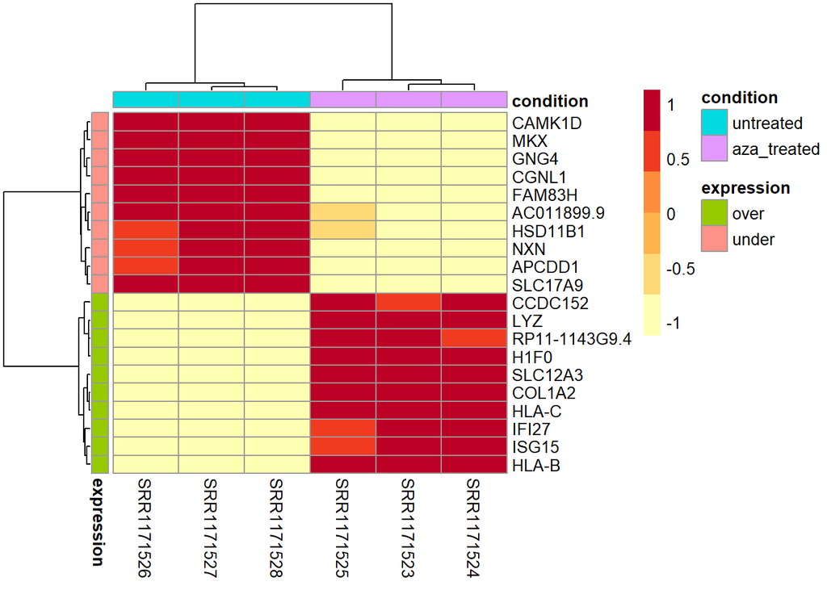

```r
normalized_counts <- counts(dds, normalize = TRUE)

# Heatmap color palette
heat_colors <- brewer.pal(n = 6, name = "YlOrRd")

normalized_counts[rownames(res_sig), ] %>%
  data.frame() %>%
  rownames_to_column("GENEID") %>%
  inner_join(y = ens2sym, by = "GENEID") %>%
  column_to_rownames("SYMBOL") %>%
  select(-GENEID) %>%
  pheatmap(
    color = heat_colors,
    cluster_rows = TRUE,
    show_rownames = TRUE,
    annotation_col = select(df_meta, condition),
    annotation_row = select(res_sig_symbol, expression),
    scale = "row"
  )
```

A heat map comparing correlation of top 10 over and under expressed genes was plotted. It can be observed that under expressed genes are highly positively correlated with untreated samples, but highly negatively correlated with treated samples, as it is expected (because after treatment under expressed gene count is differentially reduced). The same holds true with over (differentially) expressed genes, as they are initially negatively correlated with untreated samples, but once treated they become highly positively correlated.

Looking at individual genes, there is a number of genes in the over expressed side that are related to immune-response function. These genes are: LYZ, COL1A2 (extra-cellular matrix movement), HLA-B, HLA-C, IFI27 and ISG15 (6 out of 10). However, such a distinction could not be made in the under expressed side. One hypothesis for this could be that, as mentioned before, there is a set of genes in the over expressed side that are highly significantly over expressed, meaning that fewer genes could help explain cellular behavior or processes; while the same would have to be explained by a larger number of genes in the under expressed side, as genes there are less significantly differentially expressed, and therefore individual gene contribution to cellular behavior could be less meaningful.

# GSEA (Gene Set Enrichment Analysis)

```r
gene_sets <- msigdbr(species = "Homo sapiens", category = "C5") %>%
  dplyr::select(gs_name, gene_symbol)
```

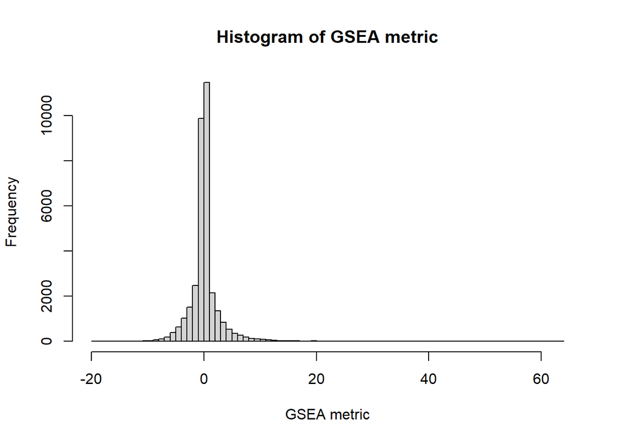

```r
resdf2 <- resdf_shrink %>%
  mutate(gsea_metric = stat) %>%
  mutate(padj_rank = -log10(padj) * sign(log2FoldChange)) %>%
  subset(!is.na(gsea_metric)) %>%
  arrange(desc(gsea_metric))

hist(resdf2$gsea_metric,
  breaks = 100,
  main = "Histogram of GSEA metric", xlab = "GSEA metric"
)
```

An histogram of GSEA metric is presented, showing a normal distribution, with a mild skew on the > 0 side, which is consistent with what was seen before (more significant genes in the over expression side).

By dropping rows where padj = NA (outliers), the ties in the preranked stats were reduced from ~12% to ~2%.

## Duplicated symbols

The gene symbols in the table below contains duplicated SYMBOLS, only the one with lowest padj (of each group of symbols) will be kept when building GSEA rankings.

```r
dupes <- duplicated(resdf_shrink$SYMBOL) |
  duplicated(resdf_shrink$SYMBOL, fromLast = TRUE)

resdf_shrink[dupes, ] %>%
  group_by(SYMBOL) %>%
  arrange(pvalue, .by_group = TRUE) %>%
  ungroup() %>%
  datatable(caption = "Duplicated gene symbols", options = list(
    pageLength = 10, scrollX = "400px"
  ))
```

|  | baseMean | log2FoldChange | lfcSE | pvalue | padj | stat | GENEID | SYMBOL |
| --- | --- | --- | --- | --- | --- | --- | --- | --- |
| 1 | 183.420772798951 | -0.130380377078817 | 0.291401099690528 | 0.188936318180258 | 0.42780401394069 | -0.447425823777889 | ENSG00000283433 | 5S_rRNA |
| 2 | 29.8413131632277 | -0.0447171527142025 | 0.272038494739423 | 0.273540311080908 | 0.548818816654446 | -0.164378033178855 | ENSG00000275305 | 5S_rRNA |
| 3 | 177.654973658306 | 0.0421686181868827 | 0.256268331130353 | 0.642982189878759 | 0.874823152649949 | 0.164548690042521 | ENSG00000277049 | 5S_rRNA |
| 4 | 17.0828023220578 | -0.00661506762376401 | 0.268596699944467 | 0.766580572461727 | 0.932320333866356 | -0.0246282535307831 | ENSG00000277411 | 5S_rRNA |
| 5 | 10.8719819198383 | -0.00055677937048137 | 0.268744573077852 | 0.966678217730876 | 0.998265565083519 | -0.00207177902833438 | ENSG00000276442 | 5S_rRNA |
| 6 | 6505.6162593394 | 0.0569275244434615 | 0.246324301163093 | 0.611212898659383 | 0.854544882167037 | 0.231108031869619 | ENSG00000202198 | 7SK |
| 7 | 100.398423788597 | -0.00983800195855195 | 0.261531581613 | 0.871226720960281 | 0.969799281345746 | -0.0376168793760047 | ENSG00000271394 | 7SK |
| 8 | 108.901330086135 | -0.0622046528051226 | 0.270186555800039 | 0.366722675770653 | 0.659315824525717 | -0.230228527177938 | ENSG00000226481 | ACTR3BP2 |
| 9 | 132.080133020008 | -0.033791689601821 | 0.26673494642298 | 0.532769415863847 | 0.805151439503509 | -0.126686398070372 | ENSG00000280263 | ACTR3BP2 |
| 10 | 2136.48150567159 | 0.00694944809553356 | 0.168995460358117 | 0.958215063437099 | 0.997027494730104 | 0.0411220992611696 | ENSG00000254978 | ALG1L9P |

[output cut: 423 more lines]

```r
ranks <- resdf2 %>%
  select(SYMBOL, gsea_metric) %>%
  distinct(SYMBOL, .keep_all = TRUE) %>%
  deframe()

gseares <- GSEA(
  geneList = ranks,
  TERM2GENE = gene_sets, eps = 0
)

gsearesdf <- as.data.frame(gseares)
```

## GSEA Dot Plot

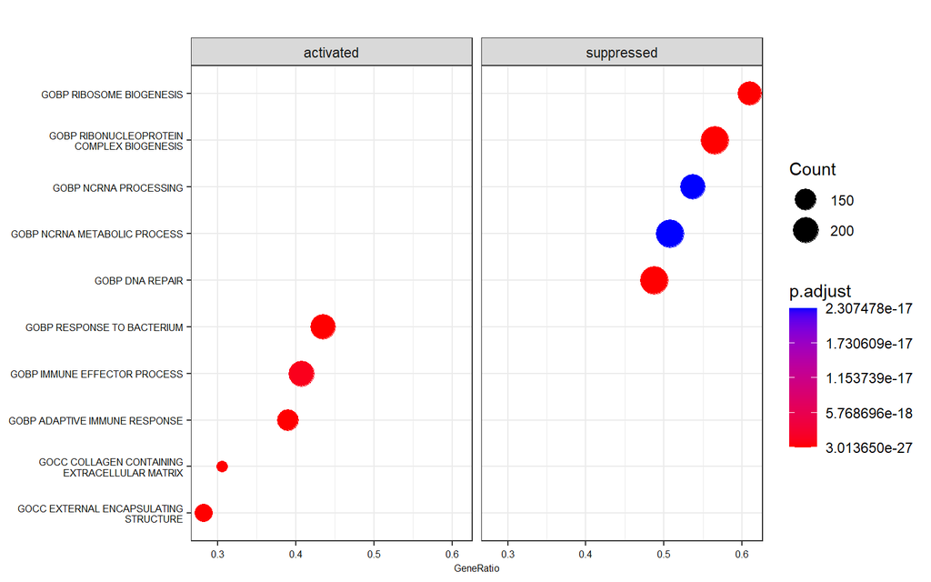

```r
dotplot(gseares,
  showCategory = 5,
  split = ".sign", font.size = 6
) + facet_grid(. ~ .sign)
```

### A note in dotplot ordering

Its important to note that dotplot() uses p.adjust together with showCategory to decide the top n gene sets that make the cut and are therefore displayed in the graph, after that, the results are ordered by GeneRatio. An implementation of the ordering logic in tidy can be seen in the code chunks below.

### A note in Gene Ontology (GO)

It could be helpful for the reader to understand relevant definitions of the nomenclature that the gene sets use:

GOBP: Biological process, refers to the biological program which the gene set pathway is thought to be responsible of. GOCC: Cellular compartment, refers to the physical location (in the cell) where the gene set pathway takes place.

http://geneontology.org/docs/ontology-documentation/

# Pathways and biological interpretation

The plot above shows the top 10 pathways (by padj), either suppressed or activated by differential gene expression. For deeper analysis, top 100 pathways (using the same sorting algorithm) were assessed, and presented in the data tables below.

## Suppressed pathways

```r
gsearesdf2_down <- gsearesdf %>%
  mutate(Count = lengths(regmatches(
    core_enrichment,
    gregexpr("/", core_enrichment)
  )) + 1) %>%
  mutate(GeneRatio = Count / setSize, .sign = sign(enrichmentScore)) %>%
  arrange(p.adjust) %>%
  # In case of ties in p.adjust the following 2 lines break the tie by GeneRatio
  group_by(p.adjust) %>%
  arrange(desc(GeneRatio), .by_group = TRUE) %>%
  ungroup() %>%
  subset(.sign < 0) %>%
  slice_head(n = 100) %>%
  arrange(desc(GeneRatio)) %>%
  select(ID, enrichmentScore, p.adjust, GeneRatio)


datatable(gsearesdf2_down, caption = "Suppressed pathways", options = list(
  pageLength = 10, scrollX = "400px"
))
```

|  | ID | enrichmentScore | p.adjust | GeneRatio |
| --- | --- | --- | --- | --- |
| 1 | GOCC_SMALL_SUBUNIT_PROCESSOME | -0.802697097152552 | 3.02768020580723e-05 | 0.810810810810811 |
| 2 | GOMF_STRUCTURAL_CONSTITUENT_OF_NUCLEAR_PORE | -0.8631730846432 | 1.57143916447966e-05 | 0.807692307692308 |
| 3 | GOMF_NUCLEOCYTOPLASMIC_CARRIER_ACTIVITY | -0.874879040975722 | 2.16632699776927e-06 | 0.785714285714286 |
| 4 | GOCC_PRERIBOSOME | -0.77375506112853 | 4.061250223886e-09 | 0.733333333333333 |
| 5 | GOMF_DNA_HELICASE_ACTIVITY | -0.754362451392246 | 5.61945278313204e-08 | 0.661971830985915 |
| 6 | GOMF_ATP_DEPENDENT_ACTIVITY_ACTING_ON_DNA | -0.719830470783138 | 9.69482446686621e-09 | 0.656565656565657 |
| 7 | GOBP_PROTEIN_LOCALIZATION_TO_CHROMOSOME | -0.745173139725935 | 1.47686373067763e-08 | 0.651162790697674 |
| 8 | GOBP_DNA_GEOMETRIC_CHANGE | -0.709638114260147 | 1.18373122164736e-07 | 0.634408602150538 |
| 9 | GOMF_RIBONUCLEOPROTEIN_COMPLEX_BINDING | -0.638913529210275 | 5.57178844248749e-07 | 0.613793103448276 |
| 10 | GOBP_RNA_EXPORT_FROM_NUCLEUS | -0.711632567131666 | 7.29213691497837e-07 | 0.609756097560976 |

[output cut: 90 more lines]

### By Location

Most suppressed pathways seem to be located in the cell nucleus (although there is one mention of GOCC_MITOCHONDRIAL_MATRIX), mostly at chromosomal regions, there are pathways specifically indicative of mitosis (GOCC_CONDENSED_CHROMOSOME, GOCC_CHROMOSOME_CENTROMERIC_REGION, GOCC_MITOTIC_SPINDLE, GOCC_SPINDLE).

### By Biological Process

Suppressed pathways are generally indicative of processes that occur during and around mitosis.

### Elucidation and further research

It can be concluded that the treatment is arresting cell growth, which can help explain its effectiveness as a cancer drug.

Further research could be conducted as to how the treatment is arresting cell growth. Because it was mentioned that suppressed pathways are over represented in mitosis (both in location and process), it would be helpful to look at genes known to be involved in arresting the cell in mitosis (e.g. p53 and RB).

For example, looking at the expression of p53 it can be noticed that it is down regulated (lfc = -0.208787), however, more p53 related genes are up regulated (n = 9) vs 5 down regulated (including p53 itself), therefore p53 could be playing a role in arresting the cell in mitosis.

Following the previous example, one biological experiment to assess the role of p53 in this particular case, would be to use CRISPR/Cas9 to knock down the gene in the AML3 cell line, obtain RNA-Seq counts, and repeat the DESeq analysis, controlling for the CRISPR samples. A similar procedure was performed by Norouzi-Barough L. et al. (https://www.ncbi.nlm.nih.gov/pmc/articles/PMC5811757/).

## Activated pathways

```r
gsearesdf2_up <- gsearesdf %>%
  mutate(Count = lengths(regmatches(
    core_enrichment,
    gregexpr("/", core_enrichment)
  )) + 1) %>%
  mutate(GeneRatio = Count / setSize, .sign = sign(enrichmentScore)) %>%
  arrange(p.adjust) %>%
  # In case of ties in p.adjust the following 2 lines break the tie by GeneRatio
  group_by(p.adjust) %>%
  arrange(desc(GeneRatio), .by_group = TRUE) %>%
  ungroup() %>%
  subset(.sign > 0) %>%
  slice_head(n = 100) %>%
  arrange(desc(GeneRatio)) %>%
  select(ID, enrichmentScore, p.adjust, GeneRatio)


datatable(gsearesdf2_up, caption = "Activated pathways", options = list(
  pageLength = 10, scrollX = "400px"
))
```

|  | ID | enrichmentScore | p.adjust | GeneRatio |
| --- | --- | --- | --- | --- |
| 1 | GOBP_NEGATIVE_REGULATION_OF_LEUKOCYTE_MEDIATED_IMMUNITY | 0.840045123068826 | 1.26901028023063e-07 | 0.548387096774194 |
| 2 | GOBP_NEGATIVE_REGULATION_OF_VIRAL_PROCESS | 0.806800597983286 | 1.07260385381639e-07 | 0.493506493506494 |
| 3 | GOBP_MYELOID_LEUKOCYTE_ACTIVATION | 0.704300309760802 | 3.9824247906217e-10 | 0.487562189054726 |
| 4 | GOCC_PHAGOCYTIC_VESICLE | 0.747932761360704 | 3.93195862123535e-09 | 0.484848484848485 |
| 5 | GOBP_CELLULAR_RESPONSE_TO_MOLECULE_OF_BACTERIAL_ORIGIN | 0.676301412305558 | 5.79833292493966e-07 | 0.479768786127168 |
| 6 | GOBP_NEGATIVE_REGULATION_OF_IMMUNE_EFFECTOR_PROCESS | 0.818853853129913 | 5.89601556941672e-11 | 0.479591836734694 |
| 7 | GOBP_PHAGOCYTOSIS | 0.6616925287003 | 5.63167420919314e-08 | 0.474885844748858 |
| 8 | GOBP_T_CELL_MEDIATED_IMMUNITY | 0.745748889695695 | 5.02682311701613e-07 | 0.470588235294118 |
| 9 | GOBP_RESPONSE_TO_MOLECULE_OF_BACTERIAL_ORIGIN | 0.685549962416649 | 3.03979875924821e-11 | 0.456928838951311 |
| 10 | GOBP_NEGATIVE_REGULATION_OF_IMMUNE_RESPONSE | 0.784022739447921 | 7.82072793100459e-14 | 0.455128205128205 |

[output cut: 90 more lines]

### By Location

Activated pathways seem to be located outside the cell (e.g. GOCC_COLLAGEN_CONTAINING_EXTRACELLULAR_MATRIX, GOCC_CELL_SUBSTRATE_JUNCTION, GOCC_EXTERNAL_ENCAPSULATING_STRUCTURE ), in the cellular membrane (e.g. GOCC_PLASMA_MEMBRANE_PROTEIN_COMPLEX, GOCC_EXTERNAL_SIDE_OF_PLASMA_MEMBRANE) and vesicles part of phagocytosis (e.g. GOCC_PHAGOCYTIC_VESICLE, GOCC_ENDOCYTIC_VESICLE).

### By Biological Process

Activated pathways are part of biological processes indicative of myeloid cell differentiation into leukocytes and corresponding activity (related to immune response).

### Elucidation and further research

The treatment is promoting myeloid cell differentiation, specifically into leukocytes. Taken in the context of the biological condition of the studied cell line (AML3), it can be understood how the treatment can be effective ameliorating the disease by suppressing cell growth and promoting cell differentiation, both hallmarks of the pathological state (i.e. uncontrolled proliferation of hematopoietic [hence undifferentiated] cells).

Further research could be conducted in order to detect particular oncogenes that may be up regulated, while not necessarily significant to an known pathway. For example, Yao-Chung Liu et al. propose that a hypomethylating agent used to treat MDS could be responsible for activating dormant oncogene SALL4 (https://www.nejm.org/doi/10.1056/NEJMoa2119771).

In the treatment in question in this analysis (Azacytidine), SALL4 is not significantly differentially expressed (padj = 0.9858676), however there are many other oncogenes to assess.

Although not presented in this analysis, GSEA plots could also be used to understand gene participation in pathways, which could be of use when there is special interest in a particular pathway.